# Adversarial Latent Autoencoder (ALAE)

The following are notes on the paper [Adversarial Latent Autoencoder](https://arxiv.org/abs/2004.04467)

with the official implementation available on [github](https://github.com/podgorskiy/ALAE)

## Vanilla GANs

Typically a GAN is composed of a generator network $G$ mapping from a space $Z$ onto a data space $X$, and a discriminator network $D$ mapping from $X$ onto $\mathbb{R}$.

The $Z$ space is characterised by a **known distribution** $p(z$). By sampling fro $p(z)$, the generator $G$ produces data representing a *synthetic* distribution $q(x)$. given training data $\mathbb{D}$ drawn from a *real* distribution $p_{\mathbb{D}}(x)$, a GAN network aims at learning $G$ so that $q(x)$ is as close to $p_{\mathbb{D}}(x)$ as possible.

The GAN problem entails finding the minimax with repsect ot he pair, ($G,D$) of the value function defined as:

$$ V(G, D) = E_{p_{\mathbb{D}}(x)} [f(D(x))] + E_{p(z)} [f(-D(G(z))] $$

where $E[.]$ donotes expectation, and $f : \mathbb{R} \rightarrow \mathbb{R}$ is a concave function.

## ALAEs

The original GAN paradigm is changed by decomposing the generator $G$ and the discriminator $D$ into two networks:

$$ G = \mathbb{G} \circ F, \text{ and } D = \mathbb{D} \circ E, $$

where $\mathbb{G} \circ F : z \rightarrow x$ is defined by $(\mathbb{G} \circ F)(z) = \mathbb{G}(F(z))$, and $\mathbb{D} \circ E : x \rightarrow z$, is defined by $(\mathbb{D} \circ E)(x) = \mathbb{D}(E(x))$

It is also assumed that the *latent spaces* at the interface between $F$ and $\mathbb{G}$, and between $E$ and $\mathbb{D}$ are the same and are defined by $w$ (Figure 1).

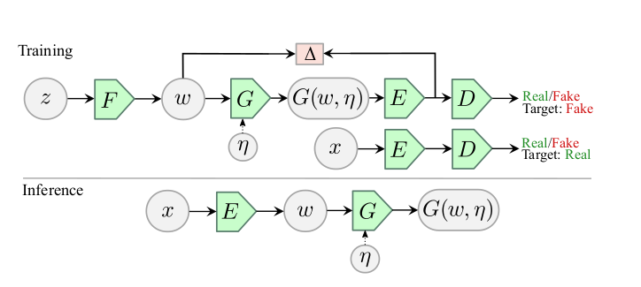

*Fig. 1: Architecture of an Adversarial Latent Autoencoder.*

An optional noise term $\eta$ can be added as dependancy of $\mathbb{G}$, deriving from a fixed known distribution $p_{\eta}(\eta)$ - $\mathbb{G}(w, \eta)$.

There is an additional goals which requires:

$$ q_F(W) = q_E(w) $$

The pairs of networks ($\mathbb{G}, E$), can be interpreted as a *generator-encoder* network that autoencodes the *latent space* $W$.

If we indicate with $\Delta (p||q)$ a measure of discrpenacy between the two distributions $p$ and $q$, we propose to achieve that goal via regularizing the GAN loss by alternating the following two optimizations:

$$ min_{F, \mathbb{G}}max_{E, \mathbb{D}} V(\mathbb{G} \circ F, \mathbb{D} \circ E) \\ min_{E,G}\Delta(F || E \circ \mathbb{G} \circ F) $$

where the left and right arguments of $\Delta$ indicate the discributions generated by the networks mapping $p(z)$, which correspond to $q_{F}(w)$ and $q_E(W)$, respectively.

The reciprocity condition is generally achieved two ways, either $x = G(E(x))$ or equvialenty $w = E(G(w))$. It can be achieved by choosing the divergence to be the expected cording reconstruction error, as follows:

$$ min_{E,G}\Delta(F || E \circ \mathbb{G} \circ F) = E_{p(z)}[|| F(z) - E \circ \mathbb{G} \circ F(z) ||_2^2] $$

Imposing reciprocity in the latent space gives the significant advantage that simple $l_2,l_1$ or other norms can eb used effectively, wheere commonly they are inappropriate for the data space (pixel space).

# Implementation

### Notes:

[1] Implementation of equilized learning rate and a few other nice things in tensorflow - [`github`](https://github.com/preritj/progressive_growing_of_GANs/blob/master/net.py)